# Assignment

Keunoo Chang

14/02/2019

Load libraries

```r
library(stringr)
library(ggplot2)
library(caret)
library(rpart)
library(rpart.plot)
```

## DATA EXPLORATION

Load the data and display summary statistics for each variable.

```r
data_full <- read.csv(file = "/Users/keunoo/R/Coursera/pml-training.csv")
data_test <- read.csv(file = "/Users/keunoo/R/Coursera/pml-testing.csv")
```

The summary indicates that there are many variables to take account and there are many non valid variables for modeling : either too many NA or too many blank values. The objective is to have a final clean database with less columns if needed. Considering the high number of columns (160) we arbitrarily decide to remove those many NA or blank values containing columns.

Preliminary analysis

```r
head(data_full)
```

```
##   X user_name raw_timestamp_part_1 raw_timestamp_part_2   cvtd_timestamp
## 1 1  carlitos           1323084231               788290 05/12/2011 11:23
## 2 2  carlitos           1323084231               808298 05/12/2011 11:23
## 3 3  carlitos           1323084231               820366 05/12/2011 11:23
## 4 4  carlitos           1323084232               120339 05/12/2011 11:23
## 5 5  carlitos           1323084232               196328 05/12/2011 11:23
## 6 6  carlitos           1323084232               304277 05/12/2011 11:23
##   new_window num_window roll_belt pitch_belt yaw_belt total_accel_belt
## 1         no         11      1.41       8.07    -94.4                3
## 2         no         11      1.41       8.07    -94.4                3
## 3         no         11      1.42       8.07    -94.4                3
## 4         no         12      1.48       8.05    -94.4                3
## 5         no         12      1.48       8.07    -94.4                3
## 6         no         12      1.45       8.06    -94.4                3
##   kurtosis_roll_belt kurtosis_picth_belt kurtosis_yaw_belt
```

[output cut: 265 more lines]

```r
dim(data_full)
```

```
## [1] 19622   160
```

```r
summary(data_full)
```

```
##        X            user_name    raw_timestamp_part_1 raw_timestamp_part_2
##  Min.   :    1   adelmo  :3892   Min.   :1.322e+09    Min.   :   294
##  1st Qu.: 4906   carlitos:3112   1st Qu.:1.323e+09    1st Qu.:252912
##  Median : 9812   charles :3536   Median :1.323e+09    Median :496380
##  Mean   : 9812   eurico  :3070   Mean   :1.323e+09    Mean   :500656
##  3rd Qu.:14717   jeremy  :3402   3rd Qu.:1.323e+09    3rd Qu.:751891
##  Max.   :19622   pedro   :2610   Max.   :1.323e+09    Max.   :998801
##
##           cvtd_timestamp  new_window    num_window      roll_belt
##  28/11/2011 14:14: 1498   no :19216   Min.   :  1.0   Min.   :-28.90
##  05/12/2011 11:24: 1497   yes:  406   1st Qu.:222.0   1st Qu.:  1.10
##  30/11/2011 17:11: 1440               Median :424.0   Median :113.00
##  05/12/2011 11:25: 1425               Mean   :430.6   Mean   : 64.41
##  02/12/2011 14:57: 1380               3rd Qu.:644.0   3rd Qu.:123.00
##  02/12/2011 13:34: 1375               Max.   :864.0   Max.   :162.00
##  (Other)         :11007
##    pitch_belt          yaw_belt       total_accel_belt kurtosis_roll_belt
##  Min.   :-55.8000   Min.   :-180.00   Min.   : 0.00             :19216
##  1st Qu.:  1.7600   1st Qu.: -88.30   1st Qu.: 3.00    #DIV/0!  :   10
##  Median :  5.2800   Median : -13.00   Median :17.00    -1.908453:    2
##  Mean   :  0.3053   Mean   : -11.21   Mean   :11.31    -0.016850:    1
##  3rd Qu.: 14.9000   3rd Qu.:  12.90   3rd Qu.:18.00    -0.021024:    1
##  Max.   : 60.3000   Max.   : 179.00   Max.   :29.00    -0.025513:    1
##                                                        (Other)  :  391
##  kurtosis_picth_belt kurtosis_yaw_belt skewness_roll_belt
##           :19216            :19216              :19216
##  #DIV/0!  :   32     #DIV/0!:  406     #DIV/0!  :    9
##  47.000000:    4                       0.000000 :    4
##  -0.150950:    3                       0.422463 :    2
##  -0.684748:    3                       -0.003095:    1
##  -1.750749:    3                       -0.010002:    1
##  (Other)  :  361                       (Other)  :  389
##  skewness_roll_belt.1 skewness_yaw_belt max_roll_belt     max_picth_belt
##           :19216             :19216     Min.   :-94.300   Min.   : 3.00
##  #DIV/0!  :   32      #DIV/0!:  406     1st Qu.:-88.000   1st Qu.: 5.00
##  0.000000 :    4                        Median : -5.100   Median :18.00
##  -2.156553:    3                        Mean   : -6.667   Mean   :12.92
##  -3.072669:    3                        3rd Qu.: 18.500   3rd Qu.:19.00
##  -6.324555:    3                        Max.   :180.000   Max.   :30.00
##  (Other)  :  361                        NA's   :19216     NA's   :19216
```

[output cut: 313 more lines]

```
##  Min.   :-446.00   Min.   :-1280.0   Min.   :-896.0   Min.   :-973.0
##  1st Qu.:-182.00   1st Qu.: -616.0   1st Qu.:   2.0   1st Qu.: 191.0
##  Median : -39.00   Median : -378.0   Median : 591.0   Median : 511.0
##  Mean   : -55.29   Mean   : -312.6   Mean   : 380.1   Mean   : 393.6
##  3rd Qu.:  26.00   3rd Qu.:  -73.0   3rd Qu.: 737.0   3rd Qu.: 653.0
##  Max.   : 291.00   Max.   :  672.0   Max.   :1480.0   Max.   :1090.0
##
##  classe
##  A:5580
##  B:3797
##  C:3422
##  D:3216
##  E:3607
##
##
```

```r
names(data_full)
```

```
##   [1] "X"                        "user_name"
##   [3] "raw_timestamp_part_1"     "raw_timestamp_part_2"
##   [5] "cvtd_timestamp"           "new_window"
##   [7] "num_window"               "roll_belt"
##   [9] "pitch_belt"               "yaw_belt"
##  [11] "total_accel_belt"         "kurtosis_roll_belt"
##  [13] "kurtosis_picth_belt"      "kurtosis_yaw_belt"
##  [15] "skewness_roll_belt"       "skewness_roll_belt.1"
##  [17] "skewness_yaw_belt"        "max_roll_belt"
##  [19] "max_picth_belt"           "max_yaw_belt"
##  [21] "min_roll_belt"            "min_pitch_belt"
##  [23] "min_yaw_belt"             "amplitude_roll_belt"
##  [25] "amplitude_pitch_belt"     "amplitude_yaw_belt"
##  [27] "var_total_accel_belt"     "avg_roll_belt"
##  [29] "stddev_roll_belt"         "var_roll_belt"
```

[output cut: 65 more lines]

```r
sapply(data_full, class)
```

```
##                        X                user_name     raw_timestamp_part_1
##                "integer"                 "factor"                "integer"
##     raw_timestamp_part_2           cvtd_timestamp               new_window
##                "integer"                 "factor"                 "factor"
##               num_window                roll_belt               pitch_belt
##                "integer"                "numeric"                "numeric"
##                 yaw_belt         total_accel_belt       kurtosis_roll_belt
##                "numeric"                "integer"                 "factor"
##      kurtosis_picth_belt        kurtosis_yaw_belt       skewness_roll_belt
##                 "factor"                 "factor"                 "factor"
##     skewness_roll_belt.1        skewness_yaw_belt            max_roll_belt
##                 "factor"                 "factor"                "numeric"
##           max_picth_belt             max_yaw_belt            min_roll_belt
##                "integer"                 "factor"                "numeric"
##           min_pitch_belt             min_yaw_belt      amplitude_roll_belt
##                "integer"                 "factor"                "numeric"
##     amplitude_pitch_belt       amplitude_yaw_belt     var_total_accel_belt
##                "integer"                 "factor"                "numeric"
##            avg_roll_belt         stddev_roll_belt            var_roll_belt
##                "numeric"                "numeric"                "numeric"
##           avg_pitch_belt        stddev_pitch_belt           var_pitch_belt
##                "numeric"                "numeric"                "numeric"
##             avg_yaw_belt          stddev_yaw_belt             var_yaw_belt
##                "numeric"                "numeric"                "numeric"
##             gyros_belt_x             gyros_belt_y             gyros_belt_z
##                "numeric"                "numeric"                "numeric"
##             accel_belt_x             accel_belt_y             accel_belt_z
##                "integer"                "integer"                "integer"
##            magnet_belt_x            magnet_belt_y            magnet_belt_z
##                "integer"                "integer"                "integer"
##                 roll_arm                pitch_arm                  yaw_arm
##                "numeric"                "numeric"                "numeric"
##          total_accel_arm            var_accel_arm             avg_roll_arm
##                "integer"                "numeric"                "numeric"
##          stddev_roll_arm             var_roll_arm            avg_pitch_arm
##                "numeric"                "numeric"                "numeric"
##         stddev_pitch_arm            var_pitch_arm              avg_yaw_arm
##                "numeric"                "numeric"                "numeric"
##           stddev_yaw_arm              var_yaw_arm              gyros_arm_x
##                "numeric"                "numeric"                "numeric"
```

[output cut: 53 more lines]

```
##                 "factor"                "integer"                "numeric"
##         avg_roll_forearm      stddev_roll_forearm         var_roll_forearm
##                "numeric"                "numeric"                "numeric"
##        avg_pitch_forearm     stddev_pitch_forearm        var_pitch_forearm
##                "numeric"                "numeric"                "numeric"
##          avg_yaw_forearm       stddev_yaw_forearm          var_yaw_forearm
##                "numeric"                "numeric"                "numeric"
##          gyros_forearm_x          gyros_forearm_y          gyros_forearm_z
##                "numeric"                "numeric"                "numeric"
##          accel_forearm_x          accel_forearm_y          accel_forearm_z
##                "integer"                "integer"                "integer"
##         magnet_forearm_x         magnet_forearm_y         magnet_forearm_z
##                "integer"                "numeric"                "numeric"
##                   classe
##                 "factor"
```

We observe that those variables containing a lot blank values are considered as factor.

Analysis of NA values

```r
colSums(is.na(data_full))
```

```
##                        X                user_name     raw_timestamp_part_1
##                        0                        0                        0
##     raw_timestamp_part_2           cvtd_timestamp               new_window
##                        0                        0                        0
##               num_window                roll_belt               pitch_belt
##                        0                        0                        0
##                 yaw_belt         total_accel_belt       kurtosis_roll_belt
##                        0                        0                        0
##      kurtosis_picth_belt        kurtosis_yaw_belt       skewness_roll_belt
##                        0                        0                        0
##     skewness_roll_belt.1        skewness_yaw_belt            max_roll_belt
##                        0                        0                    19216
##           max_picth_belt             max_yaw_belt            min_roll_belt
##                    19216                        0                    19216
##           min_pitch_belt             min_yaw_belt      amplitude_roll_belt
##                    19216                        0                    19216
##     amplitude_pitch_belt       amplitude_yaw_belt     var_total_accel_belt
##                    19216                        0                    19216
##            avg_roll_belt         stddev_roll_belt            var_roll_belt
##                    19216                    19216                    19216
##           avg_pitch_belt        stddev_pitch_belt           var_pitch_belt
##                    19216                    19216                    19216
##             avg_yaw_belt          stddev_yaw_belt             var_yaw_belt
##                    19216                    19216                    19216
##             gyros_belt_x             gyros_belt_y             gyros_belt_z
##                        0                        0                        0
##             accel_belt_x             accel_belt_y             accel_belt_z
##                        0                        0                        0
##            magnet_belt_x            magnet_belt_y            magnet_belt_z
##                        0                        0                        0
##                 roll_arm                pitch_arm                  yaw_arm
##                        0                        0                        0
##          total_accel_arm            var_accel_arm             avg_roll_arm
##                        0                    19216                    19216
##          stddev_roll_arm             var_roll_arm            avg_pitch_arm
##                    19216                    19216                    19216
##         stddev_pitch_arm            var_pitch_arm              avg_yaw_arm
##                    19216                    19216                    19216
##           stddev_yaw_arm              var_yaw_arm              gyros_arm_x
##                    19216                    19216                        0
```

[output cut: 53 more lines]

```
##                        0                        0                    19216
##         avg_roll_forearm      stddev_roll_forearm         var_roll_forearm
##                    19216                    19216                    19216
##        avg_pitch_forearm     stddev_pitch_forearm        var_pitch_forearm
##                    19216                    19216                    19216
##          avg_yaw_forearm       stddev_yaw_forearm          var_yaw_forearm
##                    19216                    19216                    19216
##          gyros_forearm_x          gyros_forearm_y          gyros_forearm_z
##                        0                        0                        0
##          accel_forearm_x          accel_forearm_y          accel_forearm_z
##                        0                        0                        0
##         magnet_forearm_x         magnet_forearm_y         magnet_forearm_z
##                        0                        0                        0
##                   classe
##                        0
```

This function helps us to detect NA values contaning columns.

Adjustments of the data to remove non numeric, NA dense and non blank variables. Also we remove the first column and the time stamp related variables assuming the target values do not depend of the time.

```r
# get numeric var names
numeric.vars <-names(data_full)[sapply(data_full, class) %in% c("integer", "numeric")]
# get only numeric variables
data_num <- data_full[, c(numeric.vars,"classe")]

# get valid vars
valid.vars <-names(data_num)[colSums(is.na(data_num)) %in% c(0)]
# get only valid variables
data_valid <- data_num[, valid.vars]

#remove X and time stamp variables
final.vars <- setdiff(colnames(data_valid),c("X","raw_timestamp_part_1","raw_timestamp_part_2"))
data_final <- data_valid[, final.vars] # get only final variables
```

Results of the adjustments

```r
summary(data_final)
```

```
##    num_window      roll_belt        pitch_belt          yaw_belt
##  Min.   :  1.0   Min.   :-28.90   Min.   :-55.8000   Min.   :-180.00
##  1st Qu.:222.0   1st Qu.:  1.10   1st Qu.:  1.7600   1st Qu.: -88.30
##  Median :424.0   Median :113.00   Median :  5.2800   Median : -13.00
##  Mean   :430.6   Mean   : 64.41   Mean   :  0.3053   Mean   : -11.21
##  3rd Qu.:644.0   3rd Qu.:123.00   3rd Qu.: 14.9000   3rd Qu.:  12.90
##  Max.   :864.0   Max.   :162.00   Max.   : 60.3000   Max.   : 179.00
##  total_accel_belt  gyros_belt_x        gyros_belt_y       gyros_belt_z
##  Min.   : 0.00    Min.   :-1.040000   Min.   :-0.64000   Min.   :-1.4600
##  1st Qu.: 3.00    1st Qu.:-0.030000   1st Qu.: 0.00000   1st Qu.:-0.2000
##  Median :17.00    Median : 0.030000   Median : 0.02000   Median :-0.1000
##  Mean   :11.31    Mean   :-0.005592   Mean   : 0.03959   Mean   :-0.1305
##  3rd Qu.:18.00    3rd Qu.: 0.110000   3rd Qu.: 0.11000   3rd Qu.:-0.0200
##  Max.   :29.00    Max.   : 2.220000   Max.   : 0.64000   Max.   : 1.6200
##   accel_belt_x       accel_belt_y     accel_belt_z     magnet_belt_x
##  Min.   :-120.000   Min.   :-69.00   Min.   :-275.00   Min.   :-52.0
##  1st Qu.: -21.000   1st Qu.:  3.00   1st Qu.:-162.00   1st Qu.:  9.0
##  Median : -15.000   Median : 35.00   Median :-152.00   Median : 35.0
##  Mean   :  -5.595   Mean   : 30.15   Mean   : -72.59   Mean   : 55.6
##  3rd Qu.:  -5.000   3rd Qu.: 61.00   3rd Qu.:  27.00   3rd Qu.: 59.0
##  Max.   :  85.000   Max.   :164.00   Max.   : 105.00   Max.   :485.0
##  magnet_belt_y   magnet_belt_z       roll_arm         pitch_arm
##  Min.   :354.0   Min.   :-623.0   Min.   :-180.00   Min.   :-88.800
##  1st Qu.:581.0   1st Qu.:-375.0   1st Qu.: -31.77   1st Qu.:-25.900
##  Median :601.0   Median :-320.0   Median :   0.00   Median :  0.000
##  Mean   :593.7   Mean   :-345.5   Mean   :  17.83   Mean   : -4.612
##  3rd Qu.:610.0   3rd Qu.:-306.0   3rd Qu.:  77.30   3rd Qu.: 11.200
##  Max.   :673.0   Max.   : 293.0   Max.   : 180.00   Max.   : 88.500
##     yaw_arm          total_accel_arm  gyros_arm_x        gyros_arm_y
##  Min.   :-180.0000   Min.   : 1.00   Min.   :-6.37000   Min.   :-3.4400
##  1st Qu.: -43.1000   1st Qu.:17.00   1st Qu.:-1.33000   1st Qu.:-0.8000
##  Median :   0.0000   Median :27.00   Median : 0.08000   Median :-0.2400
##  Mean   :  -0.6188   Mean   :25.51   Mean   : 0.04277   Mean   :-0.2571
##  3rd Qu.:  45.8750   3rd Qu.:33.00   3rd Qu.: 1.57000   3rd Qu.: 0.1400
##  Max.   : 180.0000   Max.   :66.00   Max.   : 4.87000   Max.   : 2.8400
##   gyros_arm_z       accel_arm_x       accel_arm_y      accel_arm_z
##  Min.   :-2.3300   Min.   :-404.00   Min.   :-318.0   Min.   :-636.00
##  1st Qu.:-0.0700   1st Qu.:-242.00   1st Qu.: -54.0   1st Qu.:-143.00
##  Median : 0.2300   Median : -44.00   Median :  14.0   Median : -47.00
##  Mean   : 0.2695   Mean   : -60.24   Mean   :  32.6   Mean   : -71.25
```

[output cut: 50 more lines]

```
##  Max.   :311.00000   Max.   :231.0000   Max.   : 477.00   Max.   : 923.0
##  accel_forearm_z   magnet_forearm_x  magnet_forearm_y magnet_forearm_z
##  Min.   :-446.00   Min.   :-1280.0   Min.   :-896.0   Min.   :-973.0
##  1st Qu.:-182.00   1st Qu.: -616.0   1st Qu.:   2.0   1st Qu.: 191.0
##  Median : -39.00   Median : -378.0   Median : 591.0   Median : 511.0
##  Mean   : -55.29   Mean   : -312.6   Mean   : 380.1   Mean   : 393.6
##  3rd Qu.:  26.00   3rd Qu.:  -73.0   3rd Qu.: 737.0   3rd Qu.: 653.0
##  Max.   : 291.00   Max.   :  672.0   Max.   :1480.0   Max.   :1090.0
##  classe
##  A:5580
##  B:3797
##  C:3422
##  D:3216
##  E:3607
##
```

```r
dim(data_final)
```

```
## [1] 19622    54
```

```r
head(data_final)
```

```
##   num_window roll_belt pitch_belt yaw_belt total_accel_belt gyros_belt_x
## 1         11      1.41       8.07    -94.4                3         0.00
## 2         11      1.41       8.07    -94.4                3         0.02
## 3         11      1.42       8.07    -94.4                3         0.00
## 4         12      1.48       8.05    -94.4                3         0.02
## 5         12      1.48       8.07    -94.4                3         0.02
## 6         12      1.45       8.06    -94.4                3         0.02
##   gyros_belt_y gyros_belt_z accel_belt_x accel_belt_y accel_belt_z
## 1         0.00        -0.02          -21            4           22
## 2         0.00        -0.02          -22            4           22
## 3         0.00        -0.02          -20            5           23
## 4         0.00        -0.03          -22            3           21
## 5         0.02        -0.02          -21            2           24
## 6         0.00        -0.02          -21            4           21
##   magnet_belt_x magnet_belt_y magnet_belt_z roll_arm pitch_arm yaw_arm
```

[output cut: 69 more lines]

Our final database which we will base our model have 54 columns whereas we had 160 initially. If modeling gets poor results, we might need to include back some variables.

Correlation analysis : check if some variables have strong correlation

```r
cor.data <- data.frame(round(cor(data_final[, -c(54)]), 2))
cor.data
```

```
##                      num_window roll_belt pitch_belt yaw_belt
## num_window                 1.00      0.07      -0.10     0.09
## roll_belt                  0.07      1.00      -0.22     0.82
## pitch_belt                -0.10     -0.22       1.00    -0.70
## yaw_belt                   0.09      0.82      -0.70     1.00
## total_accel_belt           0.07      0.98      -0.14     0.76
## gyros_belt_x               0.21     -0.12      -0.44     0.15
## gyros_belt_y               0.22      0.46      -0.40     0.53
## gyros_belt_z               0.07     -0.46      -0.11    -0.27
## accel_belt_x               0.13      0.26      -0.97     0.71
## accel_belt_y               0.05      0.92       0.08     0.60
## accel_belt_z              -0.05     -0.99       0.16    -0.78
## magnet_belt_x              0.10      0.35      -0.88     0.74
## magnet_belt_y              0.16     -0.21      -0.09    -0.06
## magnet_belt_z              0.12     -0.07      -0.14     0.09
## roll_arm                  -0.12     -0.37       0.17    -0.34
## pitch_arm                 -0.03      0.06      -0.16     0.14
## yaw_arm                   -0.05     -0.23       0.14    -0.23
## total_accel_arm           -0.06     -0.28       0.09    -0.24
## gyros_arm_x                0.04      0.03      -0.05     0.04
## gyros_arm_y               -0.06     -0.23       0.11    -0.22
## gyros_arm_z                0.17      0.55      -0.31     0.55
## accel_arm_x               -0.11      0.23       0.20     0.06
## accel_arm_y               -0.09     -0.79       0.22    -0.68
## accel_arm_z               -0.02      0.39       0.05     0.25
## magnet_arm_x               0.03      0.09      -0.04     0.08
## magnet_arm_y              -0.01      0.01       0.05    -0.02
## magnet_arm_z               0.02      0.02       0.00     0.01
## roll_dumbbell              0.03     -0.13      -0.35     0.10
## pitch_dumbbell            -0.15      0.06       0.23    -0.09
## yaw_dumbbell              -0.11      0.03       0.66    -0.35
## total_accel_dumbbell       0.09     -0.19      -0.32     0.05
## gyros_dumbbell_x          -0.03      0.01       0.01     0.00
## gyros_dumbbell_y           0.07      0.06      -0.03     0.05
## gyros_dumbbell_z           0.01      0.00      -0.01     0.01
## accel_dumbbell_x          -0.11      0.22       0.17     0.05
## accel_dumbbell_y           0.14     -0.26      -0.45     0.05
## accel_dumbbell_z          -0.10      0.11       0.54    -0.23
## magnet_dumbbell_x         -0.24      0.31       0.46    -0.03
## magnet_dumbbell_y          0.24     -0.29      -0.36    -0.03
```

[output cut: 809 more lines]

```
## magnet_dumbbell_y                0.08            -0.02            -0.04
## magnet_dumbbell_z                0.24            -0.04            -0.58
## roll_forearm                     0.02             0.16             0.41
## pitch_forearm                   -0.44            -0.27            -0.02
## yaw_forearm                     -0.08             0.38             0.06
## total_accel_forearm             -0.26             0.14            -0.01
## gyros_forearm_x                 -0.03             0.10             0.19
## gyros_forearm_y                  0.00             0.01             0.06
## gyros_forearm_z                  0.00             0.02             0.00
## accel_forearm_x                  0.68             0.21             0.07
## accel_forearm_y                 -0.13             0.77             0.28
## accel_forearm_z                  0.07             0.03            -0.55
## magnet_forearm_x                 1.00            -0.30            -0.13
## magnet_forearm_y                -0.30             1.00             0.24
## magnet_forearm_z                -0.13             0.24             1.00
```

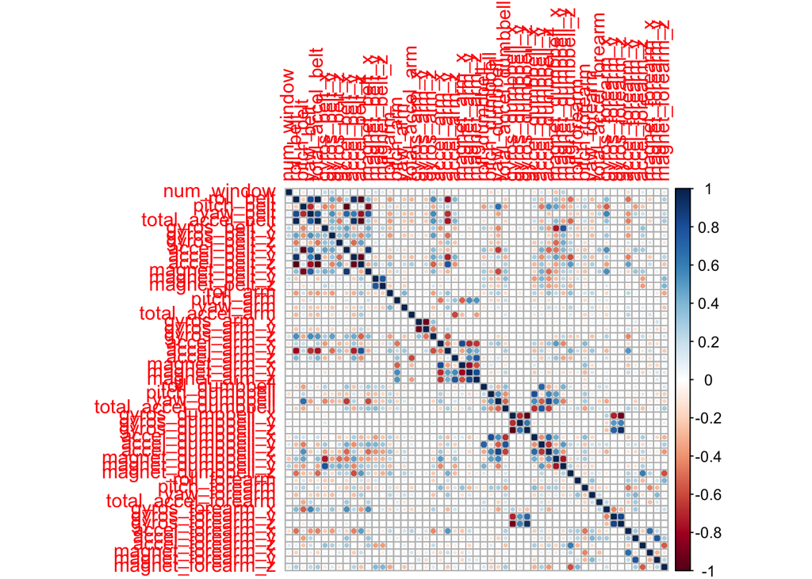

```r
library(corrplot)
corrplot(cor(data_final[, -c(54)]))
```

```r
#pairs(data_final[, c(1,2)])
```

Some correlations can be visualized among variables.

## PLOTS

Plot the target values by count

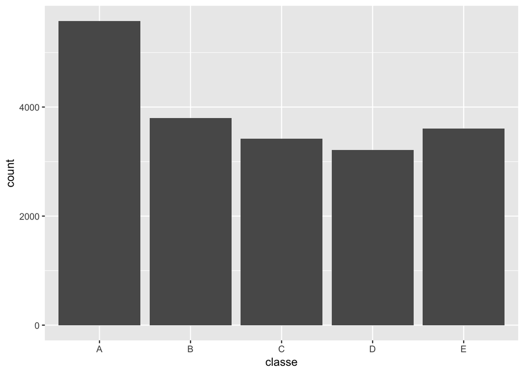

```r
ggplot(data=data_final, mapping = aes(x=classe)) + geom_bar()
```

Plot the target by numerical variable (boxplot)

```r
dim(data_final)
```

```
## [1] 19622    54
```

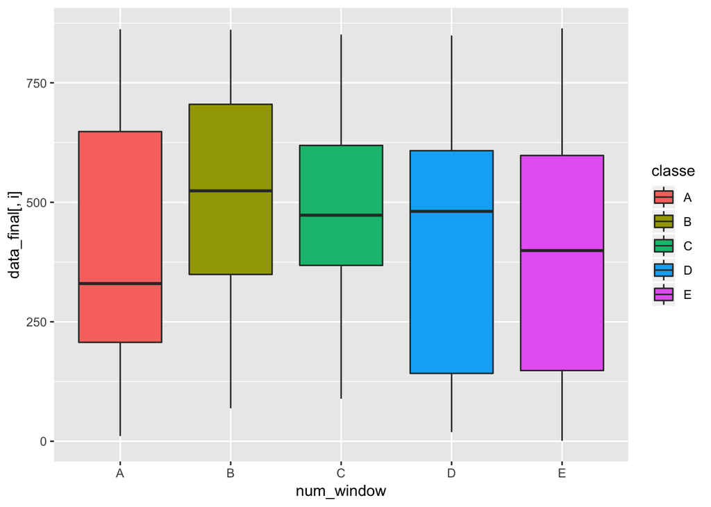

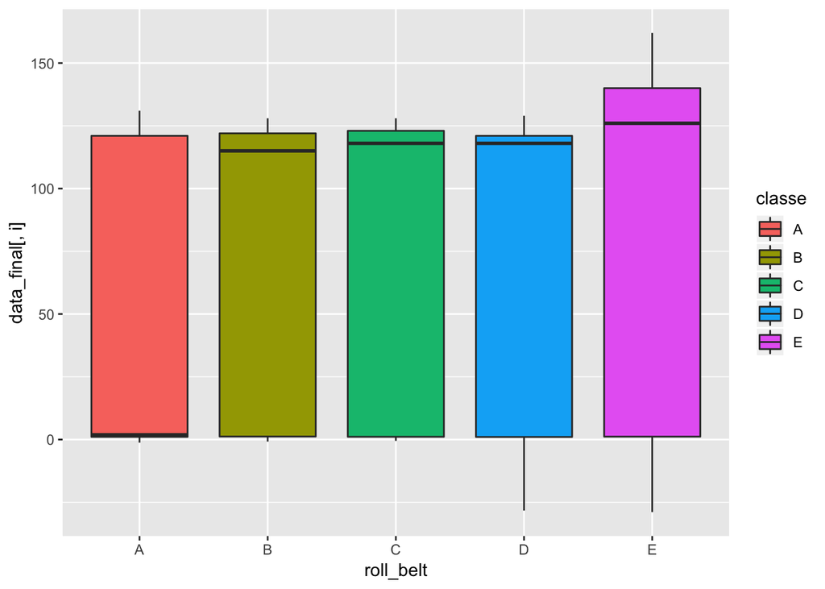

```r
for (i in c(1:2))
{
  plot <- ggplot(data=data_final, mapping = aes(x=classe, y = data_final[,i], fill = classe)) + geom_boxplot() + labs(x = colnames(data_final)[i])
  print(plot)
}
```

We observe that it is not easy to detect a clear pattern between the classe value and any of the variable taken indendently even though some graphs some strong correlation between the median and the classe : for example for the roll_belt variable, A classe has clearly a lower median vs the others.

## BUILD MODELS

Data partition using caret package

```r
partition <- createDataPartition(data_final$classe, list = FALSE, p = .75)
data.train <- data_final[partition, ]
data.test <- data_final[-partition, ]

table(data.train$classe) / nrow(data.train)
```

```
##
##         A         B         C         D         E
## 0.2843457 0.1935046 0.1744123 0.1638810 0.1838565
```

```r
table(data.test$classe) / nrow(data.test)
```

```
##
##         A         B         C         D         E
## 0.2844617 0.1935155 0.1743475 0.1639478 0.1837276
```

We verify that all classes are distributed the same way between training and testing sets.

### Model 1 - Decision tree

First tree with light parameters

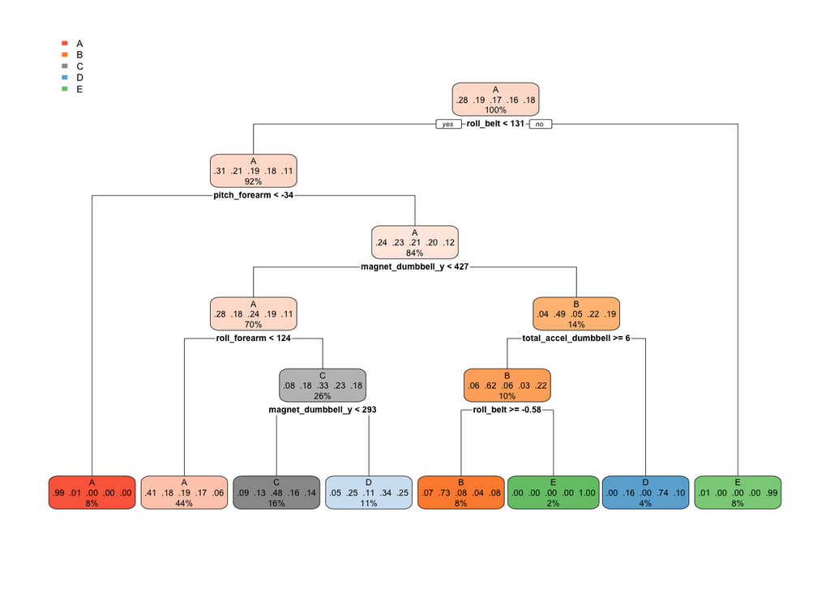

```r
dt <- rpart(classe ~ .,
            data = data.train,
            control = rpart.control(minbucket = 5, cp = .02, maxdepth = 5),
            parms = list(split = "gini"))

rpart.plot(dt)
```

```r
#Obtain the confusion matrix against the training and validation sets.

print("Training confusion matrix")
```

```
## [1] "Training confusion matrix"
```

```r
predicted <- predict(dt, type = "class")
confusionMatrix(predicted, factor(data.train$classe))
```

```
## Confusion Matrix and Statistics
##
##           Reference
## Prediction    A    B    C    D    E
##          A 3787 1163 1197 1065  381
##          B   91  910   95   45  105
##          C  211  294 1108  360  323
##          D   86  481  167  942  444
##          E   10    0    0    0 1453
##
## Overall Statistics
##
##                Accuracy : 0.5571
##                  95% CI : (0.5491, 0.5652)
##     No Information Rate : 0.2843
##     P-Value [Acc > NIR] : < 2.2e-16
##
##                   Kappa : 0.4232
##  Mcnemar's Test P-Value : < 2.2e-16
##
## Statistics by Class:
##
##                      Class: A Class: B Class: C Class: D Class: E
## Sensitivity            0.9049  0.31952  0.43163   0.3905  0.53695
## Specificity            0.6387  0.97169  0.90223   0.9043  0.99917
## Pos Pred Value         0.4987  0.73034  0.48258   0.4443  0.99316
## Neg Pred Value         0.9441  0.85615  0.88255   0.8833  0.90547
## Prevalence             0.2843  0.19350  0.17441   0.1639  0.18386
## Detection Rate         0.2573  0.06183  0.07528   0.0640  0.09872
## Detection Prevalence   0.5159  0.08466  0.15600   0.1440  0.09940
## Balanced Accuracy      0.7718  0.64561  0.66693   0.6474  0.76806
```

```r
print("Test confusion matrix")
```

```
## [1] "Test confusion matrix"
```

```r
predicted <- predict(dt, newdata = data.test, type = "class")
confusionMatrix(predicted, factor(data.test$classe))
```

```
## Confusion Matrix and Statistics
##
##           Reference
## Prediction    A    B    C    D    E
##          A 1260  372  372  360  116
##          B   32  322   31   16   48
##          C   73  114  381   98  127
##          D   26  141   71  330  132
##          E    4    0    0    0  478
##
## Overall Statistics
##
##                Accuracy : 0.565
##                  95% CI : (0.551, 0.579)
##     No Information Rate : 0.2845
##     P-Value [Acc > NIR] : < 2.2e-16
##
##                   Kappa : 0.4342
##  Mcnemar's Test P-Value : < 2.2e-16
##
## Statistics by Class:
##
##                      Class: A Class: B Class: C Class: D Class: E
## Sensitivity            0.9032  0.33930  0.44561  0.41045  0.53052
## Specificity            0.6523  0.96789  0.89825  0.90976  0.99900
## Pos Pred Value         0.5081  0.71715  0.48045  0.47143  0.99170
## Neg Pred Value         0.9443  0.85926  0.88470  0.88725  0.90434
## Prevalence             0.2845  0.19352  0.17435  0.16395  0.18373
## Detection Rate         0.2569  0.06566  0.07769  0.06729  0.09747
## Detection Prevalence   0.5057  0.09156  0.16170  0.14274  0.09829
## Balanced Accuracy      0.7778  0.65360  0.67193  0.66010  0.76476
```

More complex tree

```r
dt <- rpart(classe ~ .,
            data = data.train,
            control = rpart.control(minbucket = 5, cp = .001, maxdepth = 10),
            parms = list(split = "gini"))

#rpart.plot(dt)

print("Training confusion matrix")
```

```
## [1] "Training confusion matrix"
```

```r
predicted <- predict(dt, type = "class")
confusionMatrix(predicted, factor(data.train$classe))
```

```
## Confusion Matrix and Statistics
##
##           Reference
## Prediction    A    B    C    D    E
##          A 3904  191   76   42   41
##          B   23 2253  104   19   76
##          C   13  143 2202  107   71
##          D  206  198  149 2140  257
##          E   39   63   36  104 2261
##
## Overall Statistics
##
##                Accuracy : 0.867
##                  95% CI : (0.8614, 0.8724)
##     No Information Rate : 0.2843
##     P-Value [Acc > NIR] : < 2.2e-16
##
##                   Kappa : 0.8318
##  Mcnemar's Test P-Value : < 2.2e-16
##
## Statistics by Class:
##
##                      Class: A Class: B Class: C Class: D Class: E
## Sensitivity            0.9329   0.7911   0.8578   0.8872   0.8356
## Specificity            0.9668   0.9813   0.9725   0.9342   0.9799
## Pos Pred Value         0.9177   0.9103   0.8683   0.7254   0.9033
## Neg Pred Value         0.9731   0.9514   0.9700   0.9769   0.9636
## Prevalence             0.2843   0.1935   0.1744   0.1639   0.1839
## Detection Rate         0.2653   0.1531   0.1496   0.1454   0.1536
## Detection Prevalence   0.2890   0.1682   0.1723   0.2004   0.1701
## Balanced Accuracy      0.9498   0.8862   0.9152   0.9107   0.9077
```

```r
print("Test confusion matrix")
```

```
## [1] "Test confusion matrix"
```

```r
predicted <- predict(dt, newdata = data.test, type = "class")
confusionMatrix(predicted, factor(data.test$classe))
```

```
## Confusion Matrix and Statistics
##
##           Reference
## Prediction    A    B    C    D    E
##          A 1279   66   24   17   11
##          B    8  717   45   14   29
##          C    9   54  739   31   21
##          D   78   81   37  711   93
##          E   21   31   10   31  747
##
## Overall Statistics
##
##                Accuracy : 0.855
##                  95% CI : (0.8448, 0.8648)
##     No Information Rate : 0.2845
##     P-Value [Acc > NIR] : < 2.2e-16
##
##                   Kappa : 0.8169
##  Mcnemar's Test P-Value : < 2.2e-16
##
## Statistics by Class:
##
##                      Class: A Class: B Class: C Class: D Class: E
## Sensitivity            0.9168   0.7555   0.8643   0.8843   0.8291
## Specificity            0.9664   0.9757   0.9716   0.9295   0.9768
## Pos Pred Value         0.9155   0.8819   0.8653   0.7110   0.8893
## Neg Pred Value         0.9669   0.9433   0.9714   0.9762   0.9621
## Prevalence             0.2845   0.1935   0.1743   0.1639   0.1837
## Detection Rate         0.2608   0.1462   0.1507   0.1450   0.1523
## Detection Prevalence   0.2849   0.1658   0.1741   0.2039   0.1713
## Balanced Accuracy      0.9416   0.8656   0.9180   0.9069   0.9029
```

Accuracy has improved to 85%.

This chunk prunes the tree using the optimal complexity parameter and computes the confusion matrices.

```r
dt2 <- prune(dt, cp = dt$cptable[which.min(dt$cptable[, "xerror"]), "CP"])

#rpart.plot(dt2)

print("Training confusion matrix")
```

```
## [1] "Training confusion matrix"
```

```r
predicted <- predict(dt2, type = "class")
confusionMatrix(predicted, factor(data.train$classe))
```

```
## Confusion Matrix and Statistics
##
##           Reference
## Prediction    A    B    C    D    E
##          A 3904  191   76   42   41
##          B   23 2253  104   19   76
##          C   13  143 2202  107   71
##          D  206  198  149 2140  257
##          E   39   63   36  104 2261
##
## Overall Statistics
##
##                Accuracy : 0.867
##                  95% CI : (0.8614, 0.8724)
##     No Information Rate : 0.2843
##     P-Value [Acc > NIR] : < 2.2e-16
##
##                   Kappa : 0.8318
##  Mcnemar's Test P-Value : < 2.2e-16
##
## Statistics by Class:
##
##                      Class: A Class: B Class: C Class: D Class: E
## Sensitivity            0.9329   0.7911   0.8578   0.8872   0.8356
## Specificity            0.9668   0.9813   0.9725   0.9342   0.9799
## Pos Pred Value         0.9177   0.9103   0.8683   0.7254   0.9033
## Neg Pred Value         0.9731   0.9514   0.9700   0.9769   0.9636
## Prevalence             0.2843   0.1935   0.1744   0.1639   0.1839
## Detection Rate         0.2653   0.1531   0.1496   0.1454   0.1536
## Detection Prevalence   0.2890   0.1682   0.1723   0.2004   0.1701
## Balanced Accuracy      0.9498   0.8862   0.9152   0.9107   0.9077
```

```r
print("Test confusion matrix")
```

```
## [1] "Test confusion matrix"
```

```r
predicted <- predict(dt2, newdata = data.test, type = "class")
confusionMatrix(predicted, factor(data.test$classe))
```

```
## Confusion Matrix and Statistics
##
##           Reference
## Prediction    A    B    C    D    E
##          A 1279   66   24   17   11
##          B    8  717   45   14   29
##          C    9   54  739   31   21
##          D   78   81   37  711   93
##          E   21   31   10   31  747
##
## Overall Statistics
##
##                Accuracy : 0.855
##                  95% CI : (0.8448, 0.8648)
##     No Information Rate : 0.2845
##     P-Value [Acc > NIR] : < 2.2e-16
##
##                   Kappa : 0.8169
##  Mcnemar's Test P-Value : < 2.2e-16
##
## Statistics by Class:
##
##                      Class: A Class: B Class: C Class: D Class: E
## Sensitivity            0.9168   0.7555   0.8643   0.8843   0.8291
## Specificity            0.9664   0.9757   0.9716   0.9295   0.9768
## Pos Pred Value         0.9155   0.8819   0.8653   0.7110   0.8893
## Neg Pred Value         0.9669   0.9433   0.9714   0.9762   0.9621
## Prevalence             0.2845   0.1935   0.1743   0.1639   0.1837
## Detection Rate         0.2608   0.1462   0.1507   0.1450   0.1523
## Detection Prevalence   0.2849   0.1658   0.1741   0.2039   0.1713
## Balanced Accuracy      0.9416   0.8656   0.9180   0.9069   0.9029
```

This chunk selects the complexity parameter using cross validation.

```r
Grid <- expand.grid(cp=seq(0, 0.2, 0.001))
fitControl <- trainControl(method = "cv", number = 6)
dt3 <- train(factor(classe)~.,
                data=data.train,
                method='rpart',
                trControl = fitControl,
                metric = "Accuracy",
                tuneGrid = Grid,
                na.action = na.omit,
                parms=list(split='Gini'))

#dt3$finalModel

#plot(dt3)
#rpart.plot(dt3$finalModel, extra=4)

print("Training confusion matrix")
```

```
## [1] "Training confusion matrix"
```

```r
predicted <- predict(dt3, type = "raw")
confusionMatrix(predicted, factor(data.train$classe))
```

```
## Confusion Matrix and Statistics
##
##           Reference
## Prediction    A    B    C    D    E
##          A 4134   50   12    6    8
##          B   12 2735   28    9   16
##          C    9   26 2491   19    6
##          D   12   12   29 2362   17
##          E   18   25    7   16 2659
##
## Overall Statistics
##
##                Accuracy : 0.9771
##                  95% CI : (0.9746, 0.9795)
##     No Information Rate : 0.2843
##     P-Value [Acc > NIR] : < 2.2e-16
##
##                   Kappa : 0.971
##  Mcnemar's Test P-Value : 0.0001686
##
## Statistics by Class:
##
##                      Class: A Class: B Class: C Class: D Class: E
## Sensitivity            0.9878   0.9603   0.9704   0.9793   0.9826
## Specificity            0.9928   0.9945   0.9951   0.9943   0.9945
## Pos Pred Value         0.9819   0.9768   0.9765   0.9712   0.9758
## Neg Pred Value         0.9951   0.9905   0.9938   0.9959   0.9961
## Prevalence             0.2843   0.1935   0.1744   0.1639   0.1839
## Detection Rate         0.2809   0.1858   0.1692   0.1605   0.1807
## Detection Prevalence   0.2860   0.1902   0.1733   0.1652   0.1851
## Balanced Accuracy      0.9903   0.9774   0.9827   0.9868   0.9886
```

```r
print("Test confusion matrix")
```

```
## [1] "Test confusion matrix"
```

```r
predicted <- predict(dt3, newdata = data.test, type = "raw")
confusionMatrix(predicted, factor(data.test$classe))
```

```
## Confusion Matrix and Statistics
##
##           Reference
## Prediction    A    B    C    D    E
##          A 1361   32    4    0    3
##          B    9  873   14    8    9
##          C    7   17  811    9    5
##          D   10   10   18  779    8
##          E    8   17    8    8  876
##
## Overall Statistics
##
##                Accuracy : 0.9584
##                  95% CI : (0.9524, 0.9638)
##     No Information Rate : 0.2845
##     P-Value [Acc > NIR] : < 2.2e-16
##
##                   Kappa : 0.9474
##  Mcnemar's Test P-Value : 0.0003107
##
## Statistics by Class:
##
##                      Class: A Class: B Class: C Class: D Class: E
## Sensitivity            0.9756   0.9199   0.9485   0.9689   0.9723
## Specificity            0.9889   0.9899   0.9906   0.9888   0.9898
## Pos Pred Value         0.9721   0.9562   0.9552   0.9442   0.9553
## Neg Pred Value         0.9903   0.9810   0.9891   0.9939   0.9937
## Prevalence             0.2845   0.1935   0.1743   0.1639   0.1837
## Detection Rate         0.2775   0.1780   0.1654   0.1588   0.1786
## Detection Prevalence   0.2855   0.1862   0.1731   0.1682   0.1870
## Balanced Accuracy      0.9823   0.9549   0.9696   0.9788   0.9810
```

### Model 2 - Random forest classification

Train a random forest using cross validation

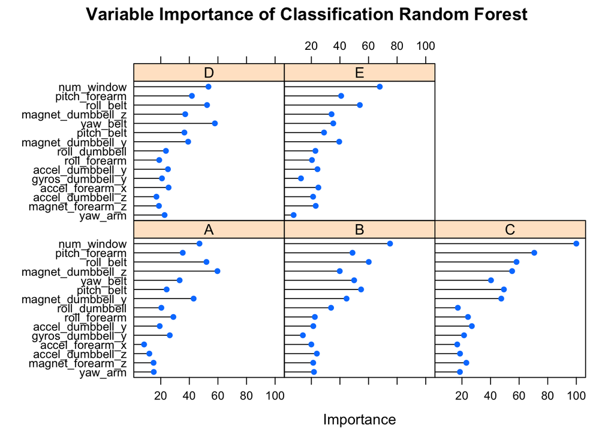

```r
control <- trainControl(method = "repeatedcv",
                        number = 5,
                        repeats = 2)

tune_grid <- expand.grid(mtry = c(20:40))

rf <- train(classe ~ .,
            data = data.train,
            method = "rf",
            ntree = 50,
            importance = TRUE,
            trControl = control,
            tuneGrid = tune_grid)
#plot(rf)
plot(varImp(rf), top = 15, main = "Variable Importance of Classification Random Forest")
```

Variable importance graphs show that the main factors are num_window, roll_belt, magnet_dumbbell, pitch belt and pitch_forearm which validates the first simple tree.s

Prediction of the model

```r
print("Training confusion matrix")
```

```
## [1] "Training confusion matrix"
```

```r
predicted <- predict(rf, type = "raw")
confusionMatrix(predicted, factor(data.train$classe))
```

```
## Confusion Matrix and Statistics
##
##           Reference
## Prediction    A    B    C    D    E
##          A 4185    0    0    0    0
##          B    0 2848    0    0    0
##          C    0    0 2567    0    0
##          D    0    0    0 2412    0
##          E    0    0    0    0 2706
##
## Overall Statistics
##
##                Accuracy : 1
##                  95% CI : (0.9997, 1)
##     No Information Rate : 0.2843
##     P-Value [Acc > NIR] : < 2.2e-16
##
##                   Kappa : 1
##  Mcnemar's Test P-Value : NA
##
## Statistics by Class:
##
##                      Class: A Class: B Class: C Class: D Class: E
## Sensitivity            1.0000   1.0000   1.0000   1.0000   1.0000
## Specificity            1.0000   1.0000   1.0000   1.0000   1.0000
## Pos Pred Value         1.0000   1.0000   1.0000   1.0000   1.0000
## Neg Pred Value         1.0000   1.0000   1.0000   1.0000   1.0000
## Prevalence             0.2843   0.1935   0.1744   0.1639   0.1839
## Detection Rate         0.2843   0.1935   0.1744   0.1639   0.1839
## Detection Prevalence   0.2843   0.1935   0.1744   0.1639   0.1839
## Balanced Accuracy      1.0000   1.0000   1.0000   1.0000   1.0000
```

```r
print("Test confusion matrix")
```

```
## [1] "Test confusion matrix"
```

```r
predicted <- predict(rf, newdata = data.test, type = "raw")
confusionMatrix(predicted, factor(data.test$classe))
```

```
## Confusion Matrix and Statistics
##
##           Reference
## Prediction    A    B    C    D    E
##          A 1395    1    0    0    0
##          B    0  948    0    0    0
##          C    0    0  855    1    0
##          D    0    0    0  803    2
##          E    0    0    0    0  899
##
## Overall Statistics
##
##                Accuracy : 0.9992
##                  95% CI : (0.9979, 0.9998)
##     No Information Rate : 0.2845
##     P-Value [Acc > NIR] : < 2.2e-16
##
##                   Kappa : 0.999
##  Mcnemar's Test P-Value : NA
##
## Statistics by Class:
##
##                      Class: A Class: B Class: C Class: D Class: E
## Sensitivity            1.0000   0.9989   1.0000   0.9988   0.9978
## Specificity            0.9997   1.0000   0.9998   0.9995   1.0000
## Pos Pred Value         0.9993   1.0000   0.9988   0.9975   1.0000
## Neg Pred Value         1.0000   0.9997   1.0000   0.9998   0.9995
## Prevalence             0.2845   0.1935   0.1743   0.1639   0.1837
## Detection Rate         0.2845   0.1933   0.1743   0.1637   0.1833
## Detection Prevalence   0.2847   0.1933   0.1746   0.1642   0.1833
## Balanced Accuracy      0.9999   0.9995   0.9999   0.9991   0.9989
```

## Test data

Input the test data to predict the 20 outcomes

```r
dim(data_test)
```

```
## [1]  20 160
```

```r
numeric.vars <-names(data_test)[sapply(data_test, class) %in% c("integer", "numeric")]
data.test.num <- data_test[, c(numeric.vars)]

valid.vars <-names(data.test.num)[colSums(is.na(data.test.num)) %in% c(0)]
data.test.valid <- data.test.num[, valid.vars]

final.vars <- setdiff(colnames(data.test.valid),c("X","raw_timestamp_part_1","raw_timestamp_part_2"))
data.test.final <- data.test.valid[, final.vars]

data.test.final <- data.test.final[,-c(54)]

predicted <- predict(rf, newdata = data.test.final, type = "raw")
predicted
```

```
##  [1] B A B A A E D B A A B C B A E E A B B B
## Levels: A B C D E
```

The 20 predictions were correct validating the model chosen.